# Data Manipulation - dplyr

Pavithra

2024-11-28

## Goal

The goal was to perform data cleaning, merging, transformation and summarization using various ‘dplyr’ functions.

## Data explanation

Datasets contains patient’s diagnosis information(patient_id, diagnosis,diagnosis_date) and treatment information(patient_id, treatment_date, drug_code).Patients are diagnosed with two types of cancer in diagnosis column(breast, colon and both). Treated with 4 types of drug combination(A,B,C and D). Diagnosis and treatment dates are given.

## Problem Statement

1. Researcher want to know the number and proportion of patients diagnosed with each type of cancer (i.e., breast cancer vs colon cancer). Note: Patients can be diagnosed with more than one type of cancer.
2. Researcher wants to know how long it takes for patients to start therapy after being diagnosed, which they consider to be helpful in understanding the quality of care for the patient. How long after their earliest diagnosis do patients start treatment? He wants know the summary statistics for each of the cancer groups in question 1.
3. Researcher wants to infer a patient’s first-line treatment regimen based on the drug or set of drugs they received in their first treatment instance. Using this approach, which treatment regimens [i.e., drug(s)] do you think would be indicated as first-line treatment for patients with… ○ breast cancer only? ○ colon cancer only? ○ both breast and colon cancer?

## Answers

The below given code will give the solutions for the above mentioned problem statments.

```r
library(readr)
d<-read.csv("C:/Users/pavip/Downloads/Patient_Diagnosis.csv")
t<-read.csv("C:/Users/pavip/Downloads/Patient_Treatment.csv")

library(dplyr)
library(lubridate)
d$diagnosis_date<-mdy(d$diagnosis_date)
t$treatment_date<-mdy(t$treatment_date)

##1
cancer<-full_join(d,t,by='patient_id',relationship = 'many-to-many')
cancer
```

```
##      patient_id diagnosis_date diagnosis_code     diagnosis treatment_date
## 1          2120     2010-01-09          174.1 Breast Cancer     2010-01-23
## 2          2120     2010-01-09          174.1 Breast Cancer     2010-01-24
## 3          2120     2010-01-09          174.1 Breast Cancer     2010-01-26
## 4          2120     2010-01-09          174.1 Breast Cancer     2010-01-26
## 5          2120     2010-01-09          174.1 Breast Cancer     2010-01-27
## 6          2120     2010-01-09          174.1 Breast Cancer     2010-01-27
## 7          2120     2010-01-09          174.1 Breast Cancer     2010-01-29
## 8          2120     2010-01-09          174.1 Breast Cancer     2010-01-29
## 9          2120     2010-01-09          174.1 Breast Cancer     2010-02-01
## 10         2120     2010-01-09          174.1 Breast Cancer     2010-02-01
## 11         2120     2010-01-09          174.1 Breast Cancer     2010-02-04
## 12         2120     2010-01-09          174.1 Breast Cancer     2010-02-04
## 13         2120     2010-01-09          174.1 Breast Cancer     2010-02-07
## 14         2120     2010-01-09          174.1 Breast Cancer     2010-02-07
```

[output cut: 2465 more lines]

```r
both<-cancer %>% group_by(patient_id) %>% filter(n_distinct(diagnosis)>1) %>% distinct(patient_id)
both
```

```
## # A tibble: 5 × 1
## # Groups:   patient_id [5]
##   patient_id
##        <int>
## 1       3757
## 2       6889
## 3       6922
## 4       6877
## 5       7230
```

```r
category <- cancer %>% group_by(patient_id, diagnosis) %>% mutate(diagnosis=case_when(patient_id %in% both$patient_id ~ 'both breast and colon', TRUE ~ diagnosis)) %>% distinct(patient_id, diagnosis)
print(category,n=47)
```

```
## # A tibble: 47 × 2
## # Groups:   patient_id, diagnosis [47]
##    patient_id diagnosis
##         <int> <chr>
##  1       2120 Breast Cancer
##  2       2720 Breast Cancer
##  3       2038 Breast Cancer
##  4       2238 Breast Cancer
##  5       2175 Breast Cancer
##  6       2475 Breast Cancer
##  7       2407 Breast Cancer
##  8       2607 Breast Cancer
##  9       2425 Breast Cancer
## 10       3025 Breast Cancer
## 11       2462 Breast Cancer
```

[output cut: 36 more lines]

```r
summary <- category %>% group_by(diagnosis) %>% summarise(count = n(), proportion = n()/n_distinct(cancer$patient_id))
summary
```

```
## # A tibble: 3 × 3
##   diagnosis             count proportion
##   <chr>                 <int>      <dbl>
## 1 Breast Cancer            31      0.660
## 2 Colon Cancer             11      0.234
## 3 both breast and colon     5      0.106
```

```r
##2
category1 <- cancer %>% mutate(diagnosis=case_when(patient_id %in% both$patient_id ~ 'both breast and colon', TRUE ~ diagnosis)) %>%
  distinct(patient_id, diagnosis, treatment_date, diagnosis_date)
e.date<- category1 %>% group_by(patient_id, diagnosis) %>% summarise(earl_diag=min(diagnosis_date), earl_treat=min(treatment_date),.groups = 'drop')
print(e.date,n=52)
```

```
## # A tibble: 47 × 4
##    patient_id diagnosis             earl_diag  earl_treat
##         <int> <chr>                 <date>     <date>
##  1       2038 Breast Cancer         2010-01-21 2010-01-24
##  2       2120 Breast Cancer         2010-01-09 2010-01-23
##  3       2175 Breast Cancer         2010-02-17 2010-02-21
##  4       2238 Breast Cancer         2010-01-21 2010-01-21
##  5       2407 Breast Cancer         2010-06-13 2010-06-19
##  6       2425 Breast Cancer         2010-12-15 2010-12-19
##  7       2462 Breast Cancer         2011-01-07 2011-01-11
##  8       2475 Breast Cancer         2010-02-17 2010-02-17
##  9       2607 Breast Cancer         2010-06-13 2010-07-03
## 10       2634 Colon Cancer          2011-02-19 2011-12-20
## 11       2720 Breast Cancer         2010-01-09 2010-01-20
## 12       2735 Breast Cancer         2011-04-18 2011-04-23
```

[output cut: 35 more lines]

```r
diff<- e.date %>% mutate(day_to_treatment=as.numeric(difftime(earl_treat, earl_diag,units='days'))) %>% distinct()
filter<-diff %>% filter(patient_id!=8827)
print(filter,n=46)
```

```
## # A tibble: 46 × 5
##    patient_id diagnosis             earl_diag  earl_treat day_to_treatment
##         <int> <chr>                 <date>     <date>                <dbl>
##  1       2038 Breast Cancer         2010-01-21 2010-01-24                3
##  2       2120 Breast Cancer         2010-01-09 2010-01-23               14
##  3       2175 Breast Cancer         2010-02-17 2010-02-21                4
##  4       2238 Breast Cancer         2010-01-21 2010-01-21                0
##  5       2407 Breast Cancer         2010-06-13 2010-06-19                6
##  6       2425 Breast Cancer         2010-12-15 2010-12-19                4
##  7       2462 Breast Cancer         2011-01-07 2011-01-11                4
##  8       2475 Breast Cancer         2010-02-17 2010-02-17                0
##  9       2607 Breast Cancer         2010-06-13 2010-07-03               20
## 10       2634 Colon Cancer          2011-02-19 2011-12-20              304
## 11       2720 Breast Cancer         2010-01-09 2010-01-20               11
## 12       2735 Breast Cancer         2011-04-18 2011-04-23                5
```

[output cut: 34 more lines]

```r
summarystat<- filter %>% group_by(diagnosis) %>% summarise(mean=round(mean(day_to_treatment,na.rm=TRUE)), median=median(day_to_treatment,na.rm=TRUE), max=max(day_to_treatment,na.rm=TRUE),min=min(day_to_treatment,na.rm=TRUE))
summarystat
```

```
## # A tibble: 3 × 5
##   diagnosis              mean median   max   min
##   <chr>                 <dbl>  <dbl> <dbl> <dbl>
## 1 Breast Cancer             5      5    20     0
## 2 Colon Cancer             30      4   304     0
## 3 both breast and colon     8      7    11     7
```

```r
##3
first_line <- inner_join(cancer, e.date, by=c('patient_id', 'treatment_date'='earl_treat'))
drug_comb <- first_line %>% group_by(patient_id, treatment_date) %>% summarise(drug_combination=paste(sort(unique(drug_code)),collapse='+'),.groups = 'drop')
merge<-inner_join(drug_comb,e.date, by='patient_id')
order <- merge %>% select(patient_id,diagnosis, treatment_date, drug_combination)
print(order,n=47)
```

```
## # A tibble: 47 × 4
##    patient_id diagnosis             treatment_date drug_combination
##         <int> <chr>                 <date>         <chr>
##  1       2038 Breast Cancer         2010-01-24     "A+B"
##  2       2120 Breast Cancer         2010-01-23     "B"
##  3       2175 Breast Cancer         2010-02-21     "A+B"
##  4       2238 Breast Cancer         2010-01-21     "B"
##  5       2407 Breast Cancer         2010-06-19     "A+B"
##  6       2425 Breast Cancer         2010-12-19     "A+B"
##  7       2462 Breast Cancer         2011-01-11     "A+B"
##  8       2475 Breast Cancer         2010-02-17     "B"
##  9       2607 Breast Cancer         2010-07-03     "B"
## 10       2634 Colon Cancer          2011-12-20     "A+B"
## 11       2720 Breast Cancer         2010-01-20     "B"
## 12       2735 Breast Cancer         2011-04-23     "A+B"
```

[output cut: 35 more lines]

```r
count<-order %>% group_by(diagnosis, drug_combination) %>% summarise(count=n(),.groups="drop")
count
```

```
## # A tibble: 10 × 3
##    diagnosis             drug_combination count
##    <chr>                 <chr>            <int>
##  1 Breast Cancer         ""                   1
##  2 Breast Cancer         "A"                  4
##  3 Breast Cancer         "A+B"               17
##  4 Breast Cancer         "B"                  7
##  5 Breast Cancer         "C"                  2
##  6 Colon Cancer          "A+B"                3
##  7 Colon Cancer          "B"                  4
##  8 Colon Cancer          "D"                  4
##  9 both breast and colon "A+B"                1
## 10 both breast and colon "C"                  4
```

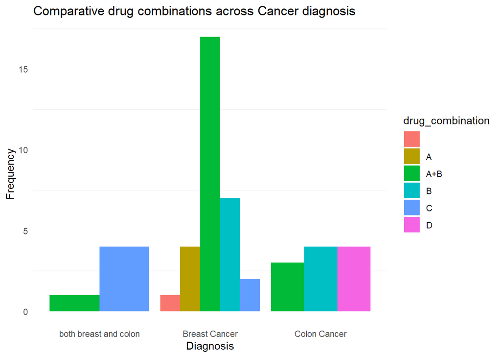

```r
library(ggplot2)
stacked_chart <- count %>% ggplot(aes(diagnosis, count, fill=drug_combination))+geom_bar(stat='identity', position = 'dodge')+theme_minimal()+labs(x="Diagnosis",y="Frequency",title="Comparative drug combinations across Cancer diagnosis")+theme(panel.grid.major = element_blank(),panel.grid.major.y =element_blank())
stacked_chart
```